# Project 2 Statistical Computing

Tyler Grimes

February 25, 2016

# Introduction

The goal of this project is to determine the average price, in dollars, that a student at UNF spends on a haircut. A sample was obtained from the STA 6106 Spring class. This was not a random sample, but we will assume it is representative of the population of UNF students. The sample is shown in the table below.

| Observation | 1 | 2 | 3 | 4 | 5 | 6 | 7 | 8 | 9 | 10 | 11 | 12 |
| --- | --- | --- | --- | --- | --- | --- | --- | --- | --- | --- | --- | --- |
| Price | 17.00 | 16.49 | 45.00 | 25.00 | 12.00 | 18.00 | 13.00 | 20.00 | 10.00 | 0.00 | 15.00 | 50.00 |

We will estimate the average price by creating a 90% confidence interval. Three different methods will be considered; a t-based confidence interval with normality assumed, a bootstrap confidence interval, and a double bootstrap interval.

## Assuming Normality

The first step now would be to verify our model assumption. A quick look at the histogram of our sample (figure 1) suggests that the population might be skewed right, or possibly bimodal. However, it is difficult to make a strong judgement with only $12$ observations.

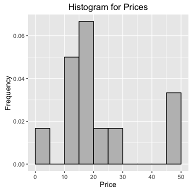

Figure 2: Histogram of sample prices

We should also look at a quantile-quantile plot (Q-Q plot) with our sample against a normal distribution (figure 2). If the sample truly does come from a normal population, the plots on the Q-Q plot should fall very close to the $y=x$ line, and should be distributed randomly above and below this line.

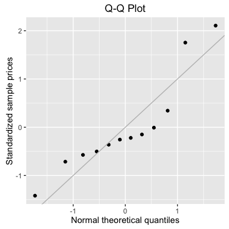

Figure 3: Q-Q Plot for sample prices with normal distirbution.

The Q-Q plot shows a clear pattern in the observations. We should be very suspect of our normality assumption. However, if we proceed anyway, the 90% confidence interval for the mean haircut price is $(12.77064, 27.47769)$.

# Bootstrap

In the previous approach, the normality assumption does not appear to be valid. And if we think about haircut prices, it is easy to imagine the distribution having three modes; students who pay $0, students who pay a medium amount of around $10-$20, and students who pay a premium amount >$50. This suggests a mixture model would be more appropriate, but then the t-based confidence interval is no longer valid.

We now consider an approach that does not depend on the population’s distribution; the non-parametric bootstrap method.

## Percentile Method

For bootsrapping in general, we use resampling with replacement to simulate random draws from the population. These simulated samples are refered to as bootstrap samples. In the most basic implementation of the bootstrap, an estimate is calulated for each bootstrap sample, which results in a distribution of estimators, and the middle 90% of these estimators is used to construct a confidence interval. This is the percentile method.

## Algorithm

Let $(x_1, ..., x_n)$ denote our random sample.

1. Obtain a bootstrap sample $(x_1^*, ..., x_n^*)$ from the original sample $(x_1, ..., x_n)$ by sampling with replacement. Compute $\widehat{\bar{x}}_{(b)}^*$.
2. Repeat 1 $B$ times to obtain $B$ estimates $(\widehat{\bar{x}}_{(1)}^*, ..., \widehat{\bar{x}}_{(B)}^*)$.
3. Order the $\widehat{\bar{x}}_{(b)}^*$’s from smallest to largest.
4. Construct the $90\%$ confidence interval by $\widehat{\bar{x}}_{(ceiling(B*0.05))}^*, \widehat{\bar{x}}_{(celing(B*0.95))}^*$

## Results

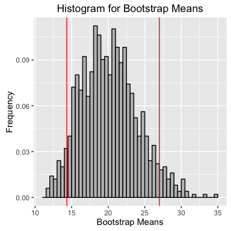

Figure 4: A histogram of means from the B bootstrap samples. The red vertical lines correspond to the cut-off points for the 90% confidence interval. The first vertical line is at the 5th percentile, the second is at the 95th percentile.

The resulting confidence interval is $(14.33333, 26.99833)$. The concern with the percentile method is that, although the confidence level is 90%, the actual coverage probability may not be 90%. That is, the procedure of constructing a percentile bootstrap interval may not actually contain the true population mean 90% of the time. Usually, this coverage probability is much lower.

# Double Bootstrap

A method for constructing a confidence interval that provides a coverage probability that is closer to the nominal level is the double bootstrap. The idea is to construct confidence intervals for several different confidence levels. We then do a second layer of resampling (simulating second-order bootstrap samples on from the first set of bootstrap samples) and use these to estimate the coverage probability for each confidence level. We can then interpolate these ($x$ = coverage probability, $y$ = confidence level) points with a Lagrange polynomial, and calculate an appropriate confidence level that will give us the desired coverage.

## Algorithm

Let $(x_1, ..., x_n)$ denote our random sample. Compute the sample mean $\bar{x}=\sum_{i=1}^nfrac{(x_i)}{n}$.

## Results

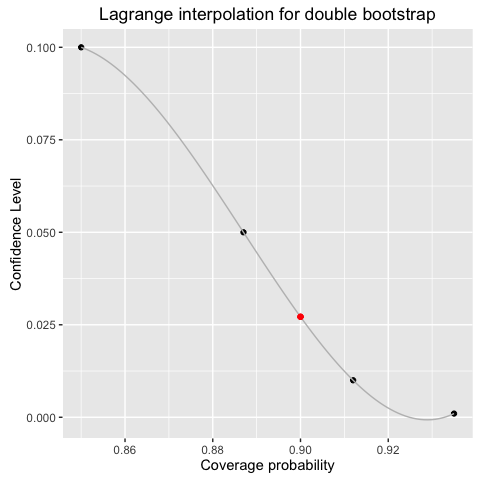

Figure 5:For the double bootstrap, four alpha levels were considered: 0.10, 0.05, 0.01, and 0.001. This graph shows the Lagrange interpolating polynomial through these four points. The red point is the estimated alpha level needed for a 90% confidence interval.

The Lagrage polynomial is shown in figure 5. For a 90% confidence interval, the estimated significance level from the double bootstrap is $\widehat{\alpha}=0.02714687$. The resulting confidence interval is $(12.54083, 29.4575)$

# Discussion

In comparing the intervals obtained from the percentile method and the double bootstrap, we see that the double bootstrap produces a wider interval. This is because of the smaller significance level used, which allows the coverage probability is much closer to the nominal level than the percentile method.

# Appendix (R code)

```r
library("ggplot2") #For nice plots.
library("knitr") #For nice tables.
library("polynom") #For Lagrange interpolation used in double bootstrap.

#Set the random number generator seed.
set.seed(3)

#Haircut data:
#   x = Amount spent on last haircut
data <- data.frame(x = c(17, 16.49, 45, 25, 12, 18, 13, 20, 10, 0, 15, 50))
x <- data$x
n <- length(data$x)

kable(matrix(c("Observation", 1:12, "Price", format(x, nsmall = 2)), nrow = 2, byrow = TRUE))

#Sample mean and standard deviation of x.
x.mean <- mean(x)
x.sd <- sd(x)

#Histogram of x.
ggplot(data.frame(Price = x), aes(Price)) +
  geom_histogram(aes(y = ..density..), breaks = seq(0, 50, 5),
                 fill = "grey", col = "black") +
  labs(title = "Histogram for Prices", x = "Price", y = "Frequency")
  #geom_vline(xintercept = x.mean, linetype = "longdash", color = "red")

##Shapiro-Wilk test
pval <- shapiro.test(x)

#Significance level used throughout.
alpha <- 0.1

#Confidence interval from normality assumption
CI <- c(x.mean + qt(alpha/2, n-1)*x.sd/sqrt(n),
        x.mean + qt(1-alpha/2, n-1)*x.sd/sqrt(n))

#QQplot of x.
ggplot(data.frame(y = (x-x.mean)/x.sd), aes(sample = y)) +
  stat_qq() +
  geom_abline(intercept = 0, slope = 1, color = "grey") +
  labs(title = "Q-Q Plot", x = "Normal theoretical quantiles",
       y = "Standardized sample prices")

B = 1000
#Create B bootstrap samples and store in an n by B matrix.
boot_samples <- matrix(sample(x, n*B, replace = TRUE), nrow = n, byrow = FALSE)

#Compute the mean for each bootstrap sample and store in a vector of length B.
boot_means <- apply(boot_samples, 2, mean)

#We'll need to obtain percentile confidence intervals again later on, so
# here we create a function that returns a percentile CI given a vector
# of estimates.
get_percentile_CI <- function(estimates, alpha = 0.1) {
  #Get the number of estimates in the vector.
  B <- length(estimates)

  #Put the estimates in ascending order.
  estimates_ordered <- sort(estimates)

  #Use the appropriate percentiles for the upper and lower confidence limit.
  CI_percentile <- c(estimates_ordered[ceiling(B*alpha/2)],
                     estimates_ordered[ceiling(B*(1 - alpha/2))])
}

#Print out the confidence interval.
CI <- get_percentile_CI(boot_means, 0.1)

ggplot(data.frame(y = boot_means), aes(y)) +
  geom_histogram(aes(y = ..density..), breaks = seq(11, 35, 0.5),
                 fill = "grey", col = "black") +
  labs(title = "Histogram for Bootstrap Means",
       x = "Bootstrap Means", y = "Frequency") +
  geom_vline(xintercept = c(CI[1], CI[2]), color = "red")

B1 = 1000
B2 = 1000

#Confidence levels to consider.
deltas <- c(0.10, 0.05, 0.01, 0.001)

#For each confidence level, we will estimate the coverage probability.
coverage <- vector(mode = "numeric", length = length(deltas))

#Create B1 bootstrap samples and store in an n by B1 matrix.
boot_samples <- matrix(sample(x, n*B1, replace = TRUE), nrow = n, byrow = FALSE)

second_boot_means <- vector("list", B1)
for(i in 1:B1) {
  #Create B2 bootstrap samples and store in an n by B2 matrix.
  second_boot_means[[i]] <- apply(matrix(sample(boot_samples[ ,i], n*B2, replace = TRUE),
                                nrow = n, byrow = FALSE), 2, mean)
}

j <- 1
for(delta in deltas) {
  CI <- NULL

  #Create confidence interval for each of the B2 bootstrap samples
  CI <- matrix(sapply(second_boot_means, get_percentile_CI, delta), nrow = 2)

  #Estimate the coverage probability.
  coverage[j] <- sum(CI[1, ] < x.mean & x.mean < CI[2, ])/B2
  j <- j + 1
}

#Calculate the Lagrange polynomial using (coverage, deltas) as (x, y) points.
L <- poly.calc(x = coverage, y = deltas)

#Evaluate the interpolated polynomial at x = alpha.
alpha.corrected <- predict(L, 1 - alpha)

CI <- get_percentile_CI(boot_means, alpha = alpha.corrected)

ggplot(data.frame(x = coverage, y = deltas)) +
  geom_point(aes(x = x, y = y)) +
  stat_function(fun = function(x) { predict(L, x) }, color = "grey") +
  labs(title = "Lagrange interpolation for double bootstrap",
       x = "Coverage probability", y = "Confidence Level") +
  geom_point(aes(x = 0.9, y = alpha.corrected), color = "red")
```